# Lab12

Bryce Butler

2024-11-15

# Task 1

```r
getwd()
```

```
## [1] "/Users/bryce./Downloads/PROJECTS/FALL224753butl0072"
```

# Task 2

## Hypothesis Testing

We want to test various null hypotheses $H_0: \mu = \mu_0$ for a sample $x_1$. Assume we know neither the population mean nor the population variance.

## Calculating $t_{\text{calc}}$

The test statistic $t_{\text{calc}}$ is given by:

$$t_{\text{calc}} = \frac{\bar{x} - \mu_0}{\frac{s}{\sqrt{n}}}$$

where: - $\bar{x}$ is the sample mean - $\mu_0$ is the hypothesized population mean - $s$ is the sample standard deviation - $n$ is the sample size

## P-Value Calculation

The p-value is calculated as:

$$P(\text{T} \geq |t_{\text{calc}}|) = P(T \geq t_{\text{calc}}) + P(T
\leq -t_{\text{calc}})$$

where $T$ follows a $t$-distribution with $n - 1$ degrees of freedom.

## Rejection Region

The rejection region for a two-tailed test at significance level $\alpha = 0.05$ is:

$$t_{\alpha/2} \text{ and } -t_{\alpha/2}$$

where $t_{\alpha/2}$ is the critical value for a two-tailed test.

## Bootstrap P-Values

Using bootstrapping, we estimate the p-value for each hypothesis by resampling the data:

$$\text{p-value} = \frac{\text{number of resampled test statistics more
extreme than } t_{\text{calc}}}{\text{total resamples}}$$

This gives a non-parametric way to evaluate the null hypothesis.

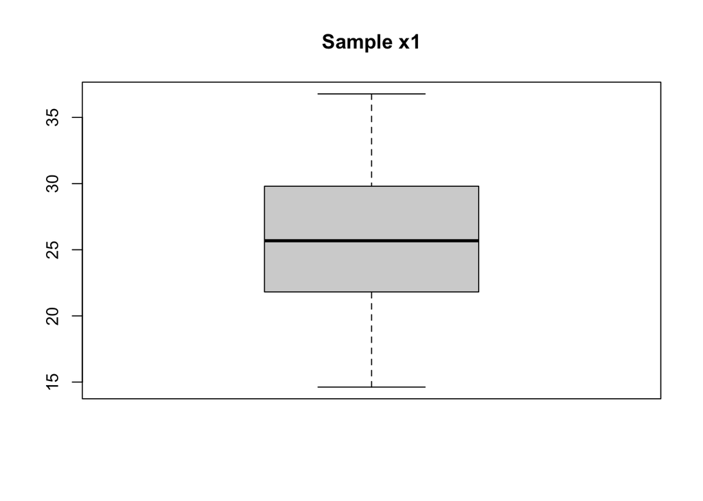

```r
# Set seed and generate sample data
set.seed(55)
x1 <- rnorm(30, mean = 25, sd = 5)
boxplot(x1, main = "Sample x1")
```

```r
# Perform one-sample t-tests for each null hypothesis
t_test_results <- list(
  t_test_22 = t.test(x1, mu = 22),
  t_test_23 = t.test(x1, mu = 23),
  t_test_24 = t.test(x1, mu = 24),
  t_test_25 = t.test(x1, mu = 25),
  t_test_26 = t.test(x1, mu = 26)
)

# Calculate tcalc for H0: mu = 24
tcalc <- (mean(x1) - 24) / (sd(x1) / sqrt(length(x1)))
tcalc
```

```
## [1] 1.326252
```

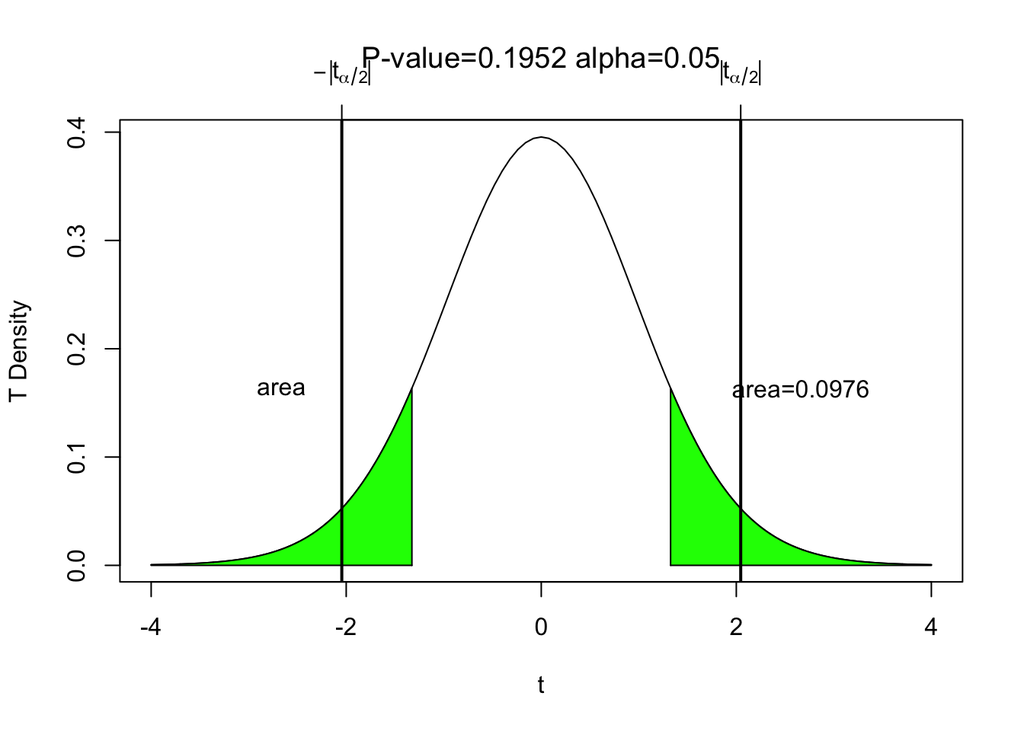

```
## $q
## [1] 2.04523
##
## $pvalue
## [1] 0.1952
```

```r
# Function to display P-value areas
mypvalue <- function(t0, xmax = 4, n = 20, alpha = 0.05) {
  va <- round(pt(-t0, df = n - 1), 4)
  pv <- 2 * va

  # Plot the t distribution
  curve(dt(x, df = n - 1), xlim = c(-xmax, xmax), ylab = "T Density", xlab = expression(t),
        main = substitute(paste("P-value=", pv, " alpha=", alpha)))

  # Set up points for the right polygon
  xcurve <- seq(t0, xmax, length = 1000)
  ycurve <- dt(xcurve, df = n - 1)

  # Set up points for the left polygon
  xlcurve <- seq(-t0, -xmax, length = 1000)
  ylcurve <- dt(xcurve, df = n - 1)

  # Shade in polygons
  polygon(c(t0, xcurve, xmax), c(0, ycurve, 0), col = "green")
  polygon(c(-t0, xlcurve, -xmax), c(0, ylcurve, 0), col = "green")

  # Plot the critical values
  q <- qt(1 - alpha / 2, n - 1)
  abline(v = c(q, -q), lwd = 2)
  axis(3, c(q, -q), c(expression(abs(t[alpha/2])), expression(-abs(t[alpha/2]))))

  # Add text annotations
  text(0.5 * (t0 + xmax), max(ycurve), substitute(paste(area, "=", va)))
  text(-0.5 * (t0 + xmax), max(ycurve), expression(area))

  return(list(q = q, pvalue = pv))
}

# Use mypvalue function to create the p-value plot
mypvalue(tcalc, xmax = 4, n = length(x1), alpha = 0.05)
```

```r
# Determine rejection region for two-tailed test with alpha = 0.05
alpha <- 0.05
df <- length(x1) - 1
t_critical <- qt(1 - alpha / 2, df)
rejection_region <- c(-t_critical, t_critical)
rejection_region
```

```
## [1] -2.04523  2.04523
```

```r
# Bootstrap function to calculate p-value
bootpval <- function(x, conf.level = 0.95, iter = 3000, mu0 = 0, test = "two") {
  n <- length(x)
  y <- x - mean(x) + mu0
  rs.mat <- xrs.mat <- c()

  for (i in 1:iter) {
    rs.mat <- cbind(rs.mat, sample(y, n, replace = TRUE))
    xrs.mat <- cbind(xrs.mat, sample(x, n, replace = TRUE))
  }

  tstat <- function(z) sqrt(n) * (mean(z) - mu0) / sd(z)
  tcalc <- tstat(x)
  ytstat <- apply(rs.mat, 2, tstat)

  pvalue <- if (test == "two") {
    length(ytstat[ytstat > abs(tcalc) | ytstat < -abs(tcalc)]) / iter
  } else if (test == "upper") {
    length(ytstat[ytstat > tcalc]) / iter
  } else {
    length(ytstat[ytstat < tcalc]) / iter
  }

  return(list(pvalue = pvalue, tcalc = tcalc, n = n, test = test))
}

# Bootstrap p-values for each hypothesis
boot_results <- list(
  boot_22 = bootpval(x = x1, mu0 = 22, test = "two"),
  boot_23 = bootpval(x = x1, mu0 = 23, test = "two"),
  boot_24 = bootpval(x = x1, mu0 = 24, test = "two"),
  boot_25 = bootpval(x = x1, mu0 = 25, test = "two"),
  boot_26 = bootpval(x = x1, mu0 = 26, test = "two")
)

# Display results
list(
  t_test_results = t_test_results,
  tcalc = tcalc,
  rejection_region = rejection_region,
  boot_results = boot_results
)
```

```
## $t_test_results
## $t_test_results$t_test_22
##
##  One Sample t-test
##
## data:  x1
## t = 3.3863, df = 29, p-value = 0.002052
## alternative hypothesis: true mean is not equal to 22
## 95 percent confidence interval:
##  23.30198 27.27320
## sample estimates:
## mean of x
##  25.28759
##
##
## $t_test_results$t_test_23
##
##  One Sample t-test
##
## data:  x1
## t = 2.3563, df = 29, p-value = 0.02543
## alternative hypothesis: true mean is not equal to 23
## 95 percent confidence interval:
##  23.30198 27.27320
## sample estimates:
## mean of x
##  25.28759
##
##
## $t_test_results$t_test_24
##
##  One Sample t-test
##
## data:  x1
## t = 1.3263, df = 29, p-value = 0.1951
## alternative hypothesis: true mean is not equal to 24
## 95 percent confidence interval:
##  23.30198 27.27320
## sample estimates:
## mean of x
```

[output cut: 92 more lines]

```
## [1] "two"
##
##
## $boot_results$boot_26
## $boot_results$boot_26$pvalue
## [1] 0.457
##
## $boot_results$boot_26$tcalc
## [1] -0.7337985
##
## $boot_results$boot_26$n
## [1] 30
##
## $boot_results$boot_26$test
## [1] "two"
```

# Task 3

## Equality of Variance Test

To test if the variances of two samples $x$ and $y$ are equal, we perform an equality of variance test:

$$H_0: \sigma_x^2 = \sigma_y^2$$
$$H_1: \sigma_x^2 \neq \sigma_y^2$$

## Two-Sample t-Test

We perform two-sample t-tests to test for differences in means under two null hypotheses.

### Hypotheses for $\mu_x - \mu_y = 0$

$$H_0: \mu_x - \mu_y = 0$$
$$H_1: \mu_x - \mu_y \neq 0$$

### Hypotheses for $\mu_x - \mu_y = 2$

$$H_0: \mu_x - \mu_y = 2$$
$$H_1: \mu_x - \mu_y \neq 2$$

The test statistic for the two-sample t-test, assuming unequal variances, is given by:

$$t = \frac{(\bar{x} - \bar{y}) - \Delta_0}{\sqrt{\frac{s_x^2}{n_x} +
\frac{s_y^2}{n_y}}}$$

where: - $\bar{x}$ and $\bar{y}$ are the sample means, - $s_x^2$ and $s_y^2$ are the sample variances, - $n_x$ and $n_y$ are the sample sizes, - $\Delta_0$ is the hypothesized difference in means (0 or 2 in this case).

If the p-value from the t-test is less than the significance level, we reject the null hypothesis.

```r
# Define x and y as per the task instructions
set.seed(30)
x <- rnorm(15, mean = 10, sd = 7)
set.seed(40)
y <- rnorm(20, mean = 12, sd = 4)

# Perform an equality of variance test
var_test_result <- var.test(x, y)
var_test_result
```

```
##
##  F test to compare two variances
##
## data:  x and y
## F = 3.3363, num df = 14, denom df = 19, p-value = 0.01596
## alternative hypothesis: true ratio of variances is not equal to 1
## 95 percent confidence interval:
##  1.260446 9.544255
## sample estimates:
## ratio of variances
##            3.33631
```

```r
# Based on the result of the var.test, decide whether to set var.equal = TRUE or FALSE in t.test
# If p-value < 0.05, variances are unequal; otherwise, they are assumed equal.
var_equal <- var_test_result$p.value > 0.05

# Perform two-sample t-tests for different null hypotheses
# H0: mu_x - mu_y = 0
t_test_0 <- t.test(x, y, mu = 0, var.equal = var_equal)

# H0: mu_x - mu_y = 2
t_test_2 <- t.test(x, y, mu = 2, var.equal = var_equal)

# Display results
list(
  var_test_result = var_test_result,
  t_test_0 = t_test_0,
  t_test_2 = t_test_2
)
```

```
## $var_test_result
##
##  F test to compare two variances
##
## data:  x and y
## F = 3.3363, num df = 14, denom df = 19, p-value = 0.01596
## alternative hypothesis: true ratio of variances is not equal to 1
## 95 percent confidence interval:
##  1.260446 9.544255
## sample estimates:
## ratio of variances
##            3.33631
##
##
## $t_test_0
##
##  Welch Two Sample t-test
##
## data:  x and y
## t = -1.7945, df = 20.248, p-value = 0.08768
## alternative hypothesis: true difference in means is not equal to 0
## 95 percent confidence interval:
##  -7.9632156  0.5950525
## sample estimates:
## mean of x mean of y
##  7.990343 11.674425
##
##
## $t_test_2
##
##  Welch Two Sample t-test
##
## data:  x and y
## t = -2.7687, df = 20.248, p-value = 0.01176
## alternative hypothesis: true difference in means is not equal to 2
## 95 percent confidence interval:
##  -7.9632156  0.5950525
## sample estimates:
## mean of x mean of y
##  7.990343 11.674425
```

# Task 4

## Equality of Variance Test

To test if the variances of two samples $x$ and $y$ are equal, we perform an equality of variance test:

$$H_0: \sigma_x^2 = \sigma_y^2$$
$$H_1: \sigma_x^2 \neq \sigma_y^2$$

If the p-value from the test is less than the significance level (usually 0.05), we conclude that the variances are significantly different.

## Two-Sample t-Test

We perform two-sample t-tests to test for differences in means under two null hypotheses.

### Hypotheses for $\mu_x - \mu_y = 0$

$$H_0: \mu_x - \mu_y = 0$$
$$H_1: \mu_x - \mu_y \neq 0$$

### Hypotheses for $\mu_x - \mu_y = 2$

$$H_0: \mu_x - \mu_y = 2$$
$$H_1: \mu_x - \mu_y \neq 2$$

The test statistic for the two-sample t-test, assuming equal variances, is given by:

$$t = \frac{(\bar{x} - \bar{y}) - \Delta_0}{\sqrt{s_p^2 \left(
\frac{1}{n_x} + \frac{1}{n_y} \right)}}$$

where: - $\bar{x}$ and $\bar{y}$ are the sample means, - $s_p^2$ is the pooled variance, - $n_x$ and $n_y$ are the sample sizes, - $\Delta_0$ is the hypothesized difference in means (0 or 2 in this case).

The pooled variance $s_p^2$ is calculated as:

$$s_p^2 = \frac{(n_x - 1)s_x^2 + (n_y - 1)s_y^2}{n_x + n_y - 2}$$

where $s_x^2$ and $s_y^2$ are the sample variances of $x$ and $y$, respectively.

If variances are not equal, we use the Welch’s t-test formula:

$$t = \frac{(\bar{x} - \bar{y}) - \Delta_0}{\sqrt{\frac{s_x^2}{n_x} +
\frac{s_y^2}{n_y}}}$$

If the p-value from the t-test is less than the significance level, we reject the null hypothesis.

```r
# Define x and y as per the task instructions
set.seed(30)
x <- rnorm(15, mean = 10, sd = 4)
set.seed(40)
y <- rnorm(20, mean = 12, sd = 4)

# Perform an equality of variance test
var_test_result <- var.test(x, y)
var_test_result
```

```
##
##  F test to compare two variances
##
## data:  x and y
## F = 1.0894, num df = 14, denom df = 19, p-value = 0.8454
## alternative hypothesis: true ratio of variances is not equal to 1
## 95 percent confidence interval:
##  0.4115743 3.1164915
## sample estimates:
## ratio of variances
##           1.089407
```

```r
# Determine whether to set var.equal = TRUE or FALSE based on the variance test
# If p-value < 0.05, variances are unequal; otherwise, they are assumed equal.
var_equal <- var_test_result$p.value > 0.05

# Perform two-sample t-tests for different null hypotheses
# H0: mu_x - mu_y = 0
t_test_0 <- t.test(x, y, mu = 0, var.equal = var_equal)

# H0: mu_x - mu_y = 2
t_test_2 <- t.test(x, y, mu = 2, var.equal = var_equal)

# Display results
list(
  var_test_result = var_test_result,
  var_equal_assumption = var_equal,
  t_test_0 = t_test_0,
  t_test_2 = t_test_2
)
```

```
## $var_test_result
##
##  F test to compare two variances
##
## data:  x and y
## F = 1.0894, num df = 14, denom df = 19, p-value = 0.8454
## alternative hypothesis: true ratio of variances is not equal to 1
## 95 percent confidence interval:
##  0.4115743 3.1164915
## sample estimates:
## ratio of variances
##           1.089407
##
##
## $var_equal_assumption
## [1] TRUE
##
## $t_test_0
##
##  Two Sample t-test
##
## data:  x and y
## t = -2.0623, df = 33, p-value = 0.04712
## alternative hypothesis: true difference in means is not equal to 0
## 95 percent confidence interval:
##  -5.60756393 -0.03803598
## sample estimates:
## mean of x mean of y
##  8.851625 11.674425
##
##
## $t_test_2
##
##  Two Sample t-test
##
## data:  x and y
## t = -3.5235, df = 33, p-value = 0.001271
## alternative hypothesis: true difference in means is not equal to 2
## 95 percent confidence interval:
##  -5.60756393 -0.03803598
## sample estimates:
## mean of x mean of y
##  8.851625 11.674425
```

# Boots2Pval function

```r
# Define the revised boot2pval function
boot2pval <- function(x1, x2, conf.level = 0.95, iter = 3000, mudiff = 0, test = "two") {
  n1 <- length(x1)
  n2 <- length(x2)
  combined_mean <- mean(c(x1, x2))

  # Center the data around the combined mean to create y1 and y2 for bootstrapping
  y1 <- x1 - mean(x1) + combined_mean
  y2 <- x2 - mean(x2) + combined_mean

  # Create matrices for resampled values
  y1rs.mat <- matrix(NA, nrow = n1, ncol = iter)
  y2rs.mat <- matrix(NA, nrow = n2, ncol = iter)

  for (i in 1:iter) {
    y1rs.mat[, i] <- sample(y1, n1, replace = TRUE)
    y2rs.mat[, i] <- sample(y2, n2, replace = TRUE)
  }

  # Calculate observed t-statistic
  tcalc <- (mean(x1) - mean(x2) - mudiff) / sqrt(var(x1) / n1 + var(x2) / n2)

  # Calculate t-statistics for resampled data
  y1_means <- colMeans(y1rs.mat)
  y2_means <- colMeans(y2rs.mat)
  y1_vars <- apply(y1rs.mat, 2, var)
  y2_vars <- apply(y2rs.mat, 2, var)

  tstat <- (y1_means - y2_means - mudiff) / sqrt(y1_vars / n1 + y2_vars / n2)

  # Calculate p-value based on bootstrap results
  if (test == "two") {
    pvalue <- mean(abs(tstat) >= abs(tcalc))
  } else if (test == "upper") {
    pvalue <- mean(tstat >= tcalc)
  } else {
    pvalue <- mean(tstat <= tcalc)
  }

  # Plot the histogram of bootstrap t-statistics
  hist(tstat, col = "lightblue", freq = FALSE, main = "Bootstrap Distribution of t-statistics",
       xlab = expression(T[stat]), las = 1)
  abline(v = c(-abs(tcalc), abs(tcalc)), col = "red", lwd = 2)

  return(list(pvalue = pvalue, tcalc = tcalc))
}
```

# Task 5

## Bootstrap Testing

We use bootstrap testing to assess the difference between two sample means under the null hypothesis that $\mu_x - \mu_y = \Delta_0$.

### Hypotheses

For each test, the null and alternative hypotheses are defined as follows:

1. **For $\Delta_0 = 0$:**
   $$H_0: \mu_x - \mu_y = 0$$
   $$H_1: \mu_x - \mu_y \neq 0$$
2. **For $\Delta_0 = 2$:**
   $$H_0: \mu_x - \mu_y = 2$$
   $$H_1: \mu_x - \mu_y \neq 2$$

### Bootstrap t-Statistic

The bootstrap t-statistic for the difference in means is calculated as:

$$t = \frac{(\bar{x} - \bar{y}) - \Delta_0}{\sqrt{\frac{s_x^2}{n_x} +
\frac{s_y^2}{n_y}}}$$

where: - $\bar{x}$ and $\bar{y}$ are the sample means, - $s_x^2$ and $s_y^2$ are the sample variances, - $n_x$ and $n_y$ are the sample sizes, - $\Delta_0$ is the hypothesized difference in means.

### Calculating the p-Value

The p-value is calculated as the proportion of bootstrap t-statistics more extreme than the observed $t_{\text{calc}}$:

$$\text{p-value} = \frac{\text{number of } |t_{\text{bootstrap}}| \geq
|t_{\text{calc}}|}{\text{total bootstrap samples}}$$

```r
# Define x and y as in Task 3
set.seed(30)
x <- rnorm(15, mean = 10, sd = 7)
set.seed(40)
y <- rnorm(20, mean = 12, sd = 4)


# Perform bootstrap tests for each hypothesis
# H0: mu_x - mu_y = 0
boot_test_0 <- boot2pval(x1 = x, x2 = y, mudiff = 0, test = "two")
```

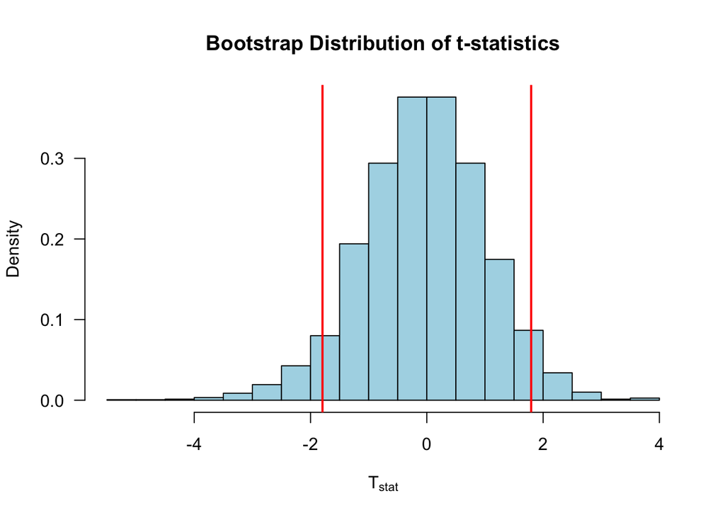

```r
# H0: mu_x - mu_y = 2
boot_test_2 <- boot2pval(x1 = x, x2 = y, mudiff = 2, test = "two")
```

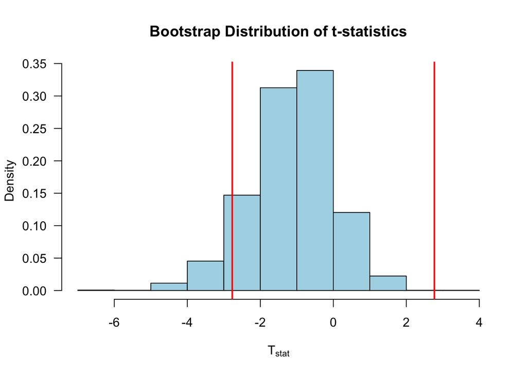

```r
# Display results
list(
  boot_test_0 = boot_test_0,
  boot_test_2 = boot_test_2
)
```

```
## $boot_test_0
## $boot_test_0$pvalue
## [1] 0.08666667
##
## $boot_test_0$tcalc
## [1] -1.794483
##
##
## $boot_test_2
## $boot_test_2$pvalue
## [1] 0.07833333
##
## $boot_test_2$tcalc
## [1] -2.768665
```

# Task 6

## Bootstrap Testing

We use bootstrap testing to assess the difference between two sample means under the null hypothesis that $\mu_x - \mu_y = \Delta_0$.

### Hypotheses

For each test, the null and alternative hypotheses are defined as follows:

1. **For $\Delta_0 = 0$:**
   $$H_0: \mu_x - \mu_y = 0$$
   $$H_1: \mu_x - \mu_y \neq 0$$
2. **For $\Delta_0 = 2$:**
   $$H_0: \mu_x - \mu_y = 2$$
   $$H_1: \mu_x - \mu_y \neq 2$$

### Bootstrap t-Statistic

The bootstrap t-statistic for the difference in means is calculated as:

$$t = \frac{(\bar{x} - \bar{y}) - \Delta_0}{\sqrt{\frac{s_x^2}{n_x} +
\frac{s_y^2}{n_y}}}$$

where: - $\bar{x}$ and $\bar{y}$ are the sample means, - $s_x^2$ and $s_y^2$ are the sample variances, - $n_x$ and $n_y$ are the sample sizes, - $\Delta_0$ is the hypothesized difference in means.

### Calculating the p-Value

The p-value is calculated as the proportion of bootstrap t-statistics more extreme than the observed $t_{\text{calc}}$:

$$\text{p-value} = \frac{\text{number of } |t_{\text{bootstrap}}| \geq
|t_{\text{calc}}|}{\text{total bootstrap samples}}$$

```r
# Define x and y as in Task 4
set.seed(30)
x <- rnorm(15, mean = 10, sd = 4)
set.seed(40)
y <- rnorm(20, mean = 12, sd = 4)


# Perform bootstrap tests for each hypothesis
# H0: mu_x - mu_y = 0
boot_test_0 <- boot2pval(x1 = x, x2 = y, mudiff = 0, test = "two")
```

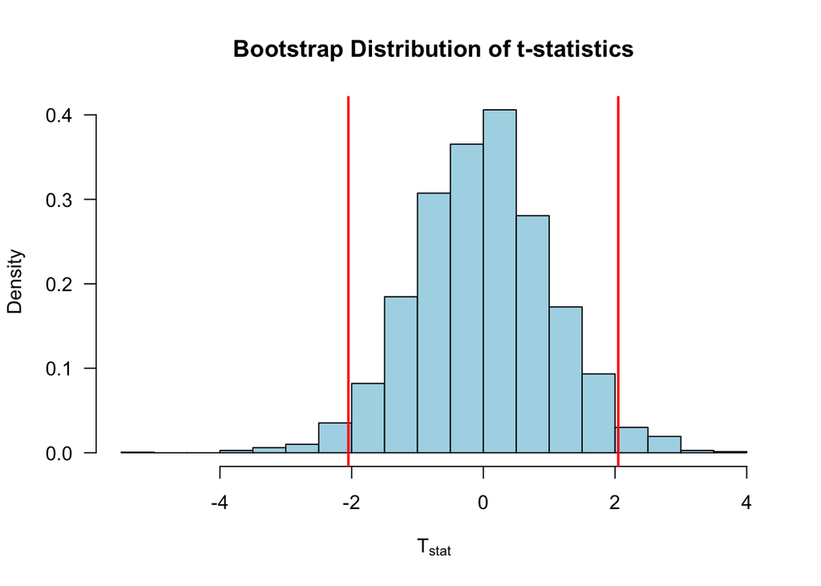

```r
# H0: mu_x - mu_y = 2
boot_test_2 <- boot2pval(x1 = x, x2 = y, mudiff = 2, test = "two")
```

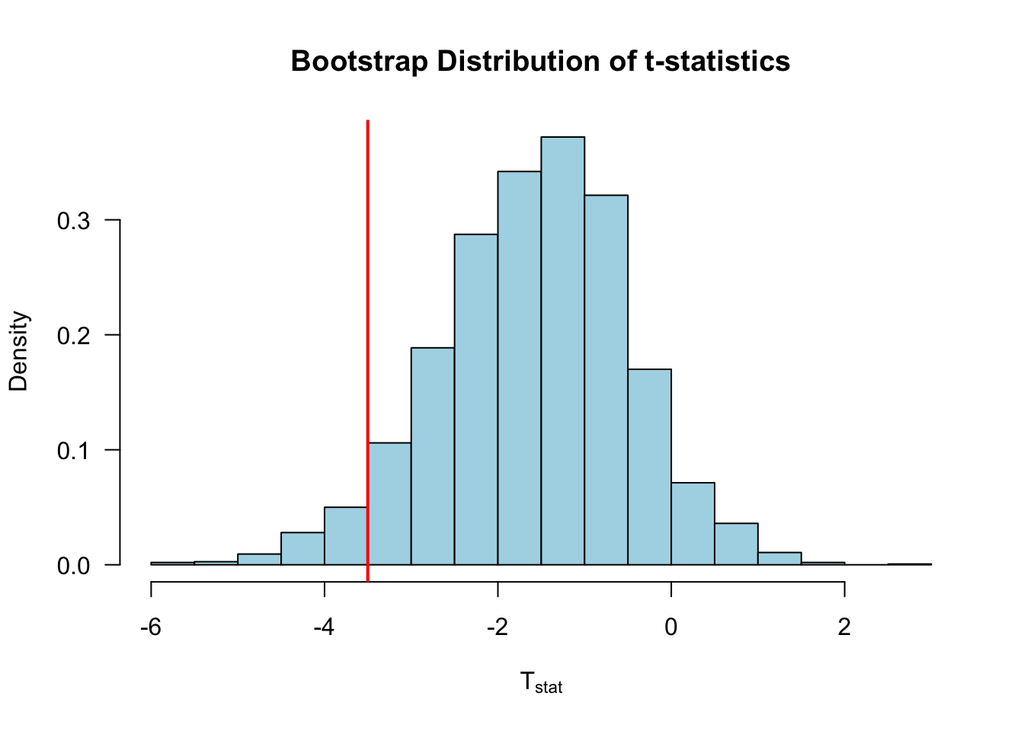

```r
# Display results
list(
  boot_test_0 = boot_test_0,
  boot_test_2 = boot_test_2
)
```

```
## $boot_test_0
## $boot_test_0$pvalue
## [1] 0.04833333
##
## $boot_test_0$tcalc
## [1] -2.049353
##
##
## $boot_test_2
## $boot_test_2$pvalue
## [1] 0.046
##
## $boot_test_2$tcalc
## [1] -3.501354
```

# Task 7

## Explanation of One-Sample t-Test Output

Given a one-sample t-test to test the hypothesis $H_0: \mu = 23$ versus $H_1: \mu \neq 23$, we obtain the following output:

1. **Test Command**: `t.test(x1, mu = 23)`
   - This performs a one-sample t-test on sample data `x1` with hypothesized mean $\mu = 23$.
2. **Test Type**: “One Sample t-test”
   - A one-sample t-test compares the mean of a single sample to a specified value.
3. **Test Statistic and p-Value**:
   - The test statistic $t$ is calculated as:
     $$t = \frac{\bar{x} - \mu_0}{s / \sqrt{n}}$$
     where:
     - $\bar{x}$ is the sample mean,
     - $\mu_0 = 23$ is the hypothesized mean,
     - $s$ is the sample standard deviation,
     - $n$ is the sample size.
   - In this case, we have $t = 2.3563$, degrees of freedom $df = 29$, and p-value $= 0.02543$.
4. **Alternative Hypothesis**:
   - The alternative hypothesis $H_1$ is that the true mean is not equal to 23 (two-tailed test).
5. **Confidence Interval**:
   - The 95% confidence interval is provided as:
     $$(23.30198, 27.27320)$$
   - This means we are 95% confident that the true population mean lies within this interval.
6. **Sample Mean**:
   - The mean of the sample `x1` is calculated as:
     $$\text{mean of } x = 25.28759$$

In summary, the test provides evidence that the sample mean differs from the hypothesized mean of 23, as indicated by the p-value and the confidence interval.

```r
# Set up the sample data
set.seed(55)
x1 <- rnorm(30, mean = 25, sd = 5)

# Perform a one-sample t-test
t_test_result <- t.test(x1, mu = 23)  # A
t_test_result
```

```
##
##  One Sample t-test
##
## data:  x1
## t = 2.3563, df = 29, p-value = 0.02543
## alternative hypothesis: true mean is not equal to 23
## 95 percent confidence interval:
##  23.30198 27.27320
## sample estimates:
## mean of x
##  25.28759
```

# Task 8

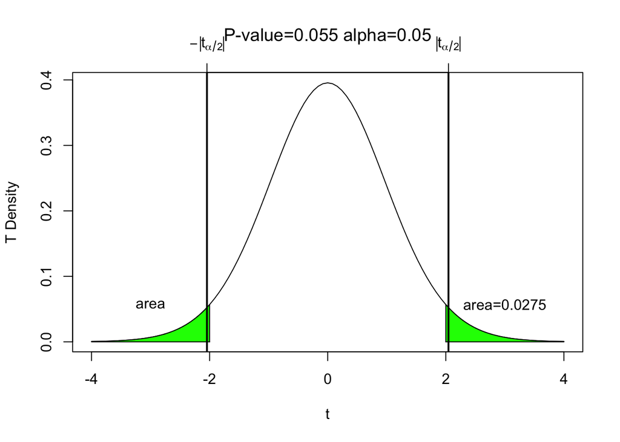

```
## $q
## [1] 2.04523
##
## $pvalue
## [1] 0.055
```

```r
FALL224753butl0072::mypvalue(t0 =2, n = 30)
```